# Clustering

Colin Gillespie

2018-11-06

## Clustering

Clustering analysis covers a wide range of numerical techniques. It is slightly different to the other methods in this chapter in that we are trying to uncover groups of observations in a data set. It is a form of what is known as unsupervised learning.

When we cluster the observations we ai to partition the data into groups that are similar to each other. Definition of what observations are close or dissimilar is often domain specific an drequires knowledge of the data being studied.

There are a large number of clustering techniques available: see the CRAN cluster [task view](http://cran.r-project.org/web/views/Cluster.html).

## Example: USA arrests

This data set contains statistics, in arrests per 100,000 residents for assault, murder, and rape in each of the 50 US states in 1973. Also given is the percent of the population living in urban areas. The data comes with the base version of R. In total there are four variables:

- `Murder`: Murder arrests (per 100,000).
- `Assault`: Assault arrests (per 100,000).
- `UrbanPop`: Percent urban population.
- `Rape`: Rape arrests (per 100,000).

The row name of the data frame gives you the state. The data set comes with R, so you can access the data set using:

```r
head(USArrests, 3)
```

```
##         Murder Assault UrbanPop Rape
## Alabama   13.2     236       58 21.2
## Alaska    10.0     263       48 44.5
## Arizona    8.1     294       80 31.0
```

## Hierarchical clustering

There are a wide range of hierarchical clustering approaches. To use hierarchical clustering, we first have to calculate the distance matrix between the different data points using the `dist` function

```r
d = dist(USArrests, method = "euclidean")
```

The default distance measure is *euclidean*. This is the squared distance between two points. There are a number of other distance measures available – see the associated help file for more details.

Next we cluster the distance matrix, using the `hclust` function

```r
fit = hclust(d, method="ward.D2")
```

The `ward.D2` method of clustering tends to find smaller, more compact clusters. Again there are a variety of other clustering methods available. We can now plot the dendogram

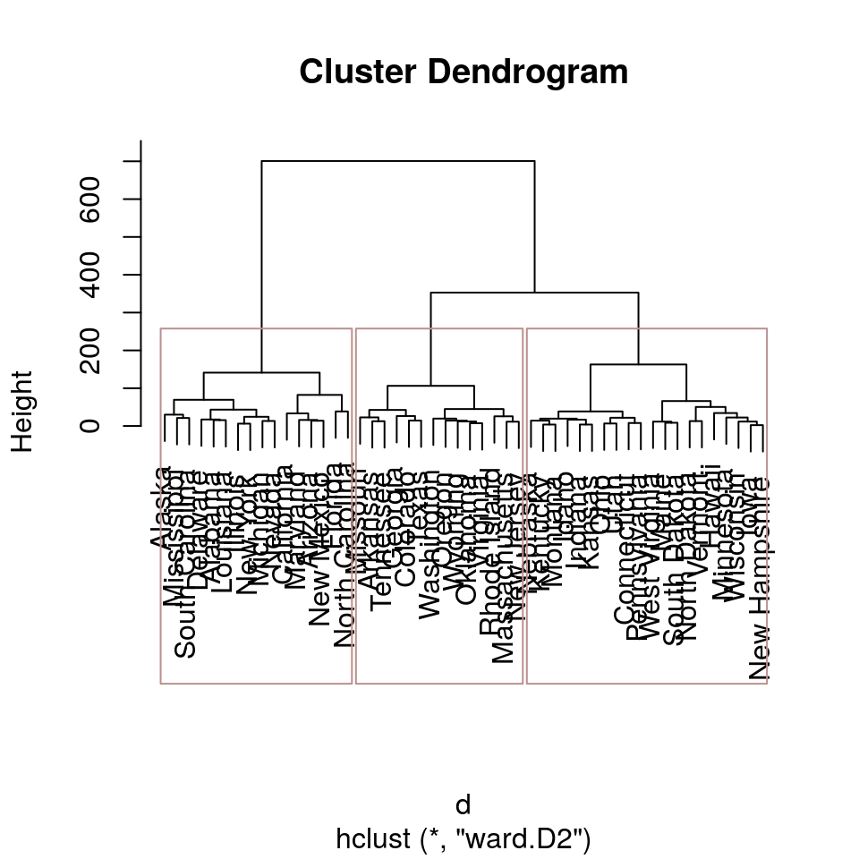

```r
plot(fit, labels=rownames(d))
```

To highlight particular clusters, we use `cutree` and `rect.hclust`

```r
groups = cutree(fit, k=3)
rect.hclust(fit, k=3, border="rosybrown")
```

## $k$-means clustering

When you carry out hierarchical clustering, you have to calculate a distance or similarity matrix between all pairs of cases. This can be prohibitive in terms of memory and CPU time.

A clustering technique that doesn’t require this matrix is $k$-means clustering. It differs from hierarchical clustering in a few ways. First, you state the number of clusters your want; although you can ``scan’’ different clusters. Second when running the algorithm, points can be reassigned to different clusters. However, with hierarchical clustering once a point has been assigned, it is fixed.

The algorithm partitions the data into $k$ groups that minimises the within-group sum of squares. If we only have a few data points, then we could compute all possible partitions. However, the number of possible combinations increase rapidly. For example, when $n=100$ and $k=5$, there are around $10^{68}$ possible partitions.

The algorithm works as follows:

1. Initialise the system where individuals are assigned to groups.
2. Propose moves of individuals from one cluster to another. If this leads to an improvement in the clustering criterion, accept the move.
3. Repeat step 2, until there is no improvement.

Since the search area is very large, we rarely explore the entire space. To run the k-mean algorithm on the USA arrest data, we use the `kmeans` function:

```r
kmeans(USArrests, centers=3)
```

Notice that we must specify the number of clusters. When the variables are measured on different scales, it is advisable to standardise the variables. In the USA data, the scales between the variables are quite different:

```r
apply(USArrests,2,mean)
```

```
##   Murder  Assault UrbanPop     Rape
##    7.788  170.760   65.540   21.232
```

This means that when we run the the clustering algorithm, the `Assault` variable will have more weight in the error function than the other variables. To get around this problem, we standardise the matrix so that each variable has a mean of zero and standard deviation of one. This is straightforward is we use the `scale` function

```r
std_usa = scale(USArrests)
```

Each variable now has mean zero and standard deviation one. We can rerun

```r
kmeans(std_usa, centers=3)
```

We should also redo the hierarchical clustering using the scaled data, i.e.

```r
plot(hclust(dist(std_usa)))
```